# Practical 1:An Introduction to R

Burhanudin Badiuzaman

2024-08-26

In my study we’ll following practicals will use the London Borough of Camden as their case study area.

In this tutorial we will:

- Download a Census data pack from the CDRC Data website
- Load the data into R using RStudio
- View the raw data in R
- Subset data in R
- Merge data in R

Our first step is to set the working directory. This is so R knows where to open and save files to. It is recommended that you set the working directory to an appropriate space in your computers work space.

```r
getwd()
```

```
## [1] "/Users/burhanudin/Study_burhanudin_6/Spatial Data Analysis and Visualisation in R/Project 1"
```

## Set the working directory

```r
setwd("/Users/burhanudin/Study_burhanudin_6/Spatial Data Analysis and Visualisation in R/Project 1")
```

Our next steps are to load the data into R.

## Loading data and data formatting in R

We can read CSVs into R using the read.csv() function as demonstrated below. This requires us to identify the file location within our workspace, and also assign an object name for our data in R.

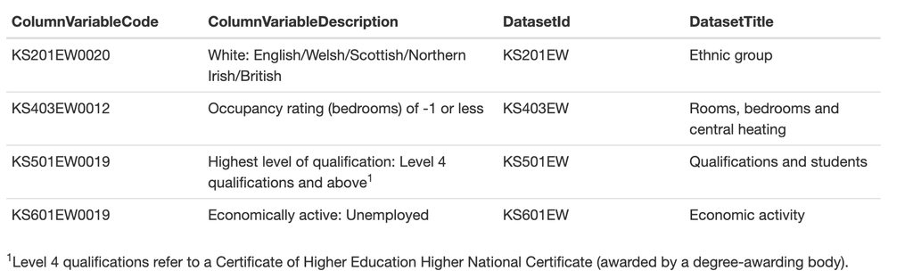

Different census dataset

# loads a csv, remember to correctly input the file location within your working directory

```r
Ethnicity <- read.csv("data/tables/KS201EW_oa11.csv",header=TRUE, stringsAsFactors=FALSE)
Rooms <- read.csv("data/tables/KS403EW_oa11.csv", header=TRUE, stringsAsFactors=FALSE)
Qualifications <- read.csv("data/tables/KS501EW_oa11.csv",header=TRUE, stringsAsFactors=FALSE)
Employment <- read.csv("data/tables/KS601EW_oa11.csv",header=TRUE, stringsAsFactors=FALSE)
```

## Viewing data

```r
# to view the top 6 cases of a data frame
head(Employment)
```

```
##   GeographyCode KS601EW0001 KS601EW0002 KS601EW0003 KS601EW0004 KS601EW0005
## 1     E00004120         264           9         125          47           5
## 2     E00004121         186           9          87          44           5
## 3     E00004122         165          13          72          38           2
## 4     E00004123         214          20          91          56           6
## 5     E00004124         131           6          68          16           5
## 6     E00004125         234          11         125          41           9
##   KS601EW0006 KS601EW0007 KS601EW0008 KS601EW0009 KS601EW0010 KS601EW0011
## 1           7          25          28           8           1           9
## 2           2          17           6           8           4           4
## 3           2           9           9          10           2           8
## 4           3           9          13          12           0           4
## 5           1          11           8           7           3           6
## 6           2          15          13           7           2           9
##   KS601EW0012 KS601EW0013 KS601EW0014 KS601EW0015 KS601EW0016 KS601EW0017
```

[output cut: 20 more lines]

## Observing column names

To observe the column names for each dataset we can use a simple names() function. It is also possible to work out their order in the columns from observing the results of this function.

```r
# view column names of a dataframe
names(Employment)
```

```
##  [1] "GeographyCode" "KS601EW0001"   "KS601EW0002"   "KS601EW0003"
##  [5] "KS601EW0004"   "KS601EW0005"   "KS601EW0006"   "KS601EW0007"
##  [9] "KS601EW0008"   "KS601EW0009"   "KS601EW0010"   "KS601EW0011"
## [13] "KS601EW0012"   "KS601EW0013"   "KS601EW0014"   "KS601EW0015"
## [17] "KS601EW0016"   "KS601EW0017"   "KS601EW0018"   "KS601EW0019"
## [21] "KS601EW0020"   "KS601EW0021"   "KS601EW0022"   "KS601EW0023"
## [25] "KS601EW0024"   "KS601EW0025"   "KS601EW0026"   "KS601EW0027"
## [29] "KS601EW0028"   "KS601EW0029"
```

We will cover more data exploration techniques in the forthcoming practical.

## Selecting columns

```r
# selecting specific columns only
# note this action overwrites the labels you made for the original data,
# so if you make a mistake you will need to reload the data into R

Ethnicity <- Ethnicity[, c(1, 21)]
Rooms <- Rooms[, c(1, 13)]
Employment <- Employment[, c(1, 20)]
Qualifications <- Qualifications[, c(1, 20)]
```

## Renaming column headers

Next we want to change the names of the codes to ease our interpretation. We can do this using the names().

If we wanted to change an individual column name we could follow the approach detailed below. In this example, we tell R that we are interested in setting to the name Unemployed to the 2nd column header in the data.

```r
# to change an individual column name
names(Employment)[2] <- "Unemployed"
```

However, we want to name both column headers in all of our data. To do this we can enter the following code. The c() function allows us to concatenate multiple values within one command.

```r
# to change both column names
names(Ethnicity)<- c("OA", "White_British")
names(Rooms)<- c("OA", "Low_Occupancy")
names(Employment)<- c("OA", "Unemployed")
names(Qualifications)<- c("OA", "Qualification")
```

## Joining data in R

We next want to combine the data into a single dataset. Joining two data frames together requires a common field, or column, between them. In this case, it is the OA field. In this field each OA has a unique ID (or OA name), this IDs can be used to identify each OA between each of the datasets. In R the merge() function joins two datasets together and creates a new object. As we are seeking to join four datasets we need to undertake multiple steps as follows.

```r
#1 Merge Ethnicity and Rooms to create a new object called "merged_data_1"
merged_data_1 <- merge(Ethnicity, Rooms, by="OA")

#2 Merge the "merged_data_1" object with Employment to create a new merged data object
merged_data_2 <- merge(merged_data_1, Employment, by="OA")

#3 Merge the "merged_data_2" object with Qualifications to create a new data object
Census.Data <- merge(merged_data_2, Qualifications, by="OA")

#4 Remove the "merged_data" objects as we won't need them anymore
rm(merged_data_1, merged_data_2)
```

Our newly formed Census.Data object contains all four variables.

## Exporting Data

You can now save this file to your workspace folder. We will use this data in the forthcoming practicals. Here we are using the write.csv() function. We have told the function not to print off the row names (the numbers on the left of the data) as we won’t need them. We will save the data as practical_data.csv to our working directory. Remember R is case sensitive so take note of when object names are capitalised.

```r
# Writes the data to a csv named "practical_data" in your file directory
write.csv(Census.Data, "practical_data.csv", row.names=F)
```